# Introduction to R

## Lists, a more flexible data frame

A list in R is similar to your to-do list at work or school: the different items on that list most likely differ in length, characteristic, and type of activity that has to be done.

A list in R allows you to gather a variety of objects under one name (that is, the name of the list) in an ordered way. These objects can be matrices, vectors, data frames, even other lists, etc. It is not even required that these objects are related to each other in any way.

You could say that a list is some kind super data type: you can store practically any piece of information in it!

To construct a list you use the function `list()`:

```r
my_vec = 1:9

my_matrix = matrix(1:12, byrow=T, nrow=6)

my_df = planets_df

my_list = list(my_vec, my_matrix, "planet"=my_df)

print(my_list)
```

```
[[1]]
[1] 1 2 3 4 5 6 7 8 9

[[2]]
     [,1] [,2]
[1,]    1    2
[2,]    3    4
[3,]    5    6
[4,]    7    8
[5,]    9   10
[6,]   11   12

$planet
     Name               Type Diameter Rotation Rings
1 Mercury Terrestrial planet    0.382    58.64 FALSE
2   Venus Terrestrial planet    0.949  -243.02 FALSE
3   Earth Terrestrial planet    1.000     1.00 FALSE
4    Mars Terrestrial planet    0.532     1.03 FALSE
5 Jupiter          Gas giant   11.209     0.41  TRUE
6  Saturn          Gas giant    9.449     0.43  TRUE
7  Uranus          Gas giant    4.007    -0.72  TRUE
8 Neptune          Gas giant    3.883     0.67  TRUE
```

To grab the first component of the list: `my_list[[ 1 ]]`

If the componets have names, you can also refer to the names of the components, with `[[ ]]` or with the `$` sign.

```r
print(my_list[[ 3 ]])
```

| Name | Type | Diameter | Rotation | Rings |
| --- | --- | --- | --- | --- |
| Mercury | Terrestrial planet | 0.382 | 58.64 | FALSE |
| Venus | Terrestrial planet | 0.949 | -243.02 | FALSE |
| Earth | Terrestrial planet | 1.000 | 1.00 | FALSE |
| Mars | Terrestrial planet | 0.532 | 1.03 | FALSE |
| Jupiter | Gas giant | 11.209 | 0.41 | TRUE |
| Saturn | Gas giant | 9.449 | 0.43 | TRUE |
| Uranus | Gas giant | 4.007 | -0.72 | TRUE |
| Neptune | Gas giant | 3.883 | 0.67 | TRUE |

```r
print(my_list[["planet"]])
```

| Name | Type | Diameter | Rotation | Rings |
| --- | --- | --- | --- | --- |
| Mercury | Terrestrial planet | 0.382 | 58.64 | FALSE |
| Venus | Terrestrial planet | 0.949 | -243.02 | FALSE |
| Earth | Terrestrial planet | 1.000 | 1.00 | FALSE |
| Mars | Terrestrial planet | 0.532 | 1.03 | FALSE |
| Jupiter | Gas giant | 11.209 | 0.41 | TRUE |
| Saturn | Gas giant | 9.449 | 0.43 | TRUE |
| Uranus | Gas giant | 4.007 | -0.72 | TRUE |
| Neptune | Gas giant | 3.883 | 0.67 | TRUE |

```r
print(my_list$planet)
```

| Name | Type | Diameter | Rotation | Rings |
| --- | --- | --- | --- | --- |
| Mercury | Terrestrial planet | 0.382 | 58.64 | FALSE |
| Venus | Terrestrial planet | 0.949 | -243.02 | FALSE |
| Earth | Terrestrial planet | 1.000 | 1.00 | FALSE |
| Mars | Terrestrial planet | 0.532 | 1.03 | FALSE |
| Jupiter | Gas giant | 11.209 | 0.41 | TRUE |
| Saturn | Gas giant | 9.449 | 0.43 | TRUE |
| Uranus | Gas giant | 4.007 | -0.72 | TRUE |
| Neptune | Gas giant | 3.883 | 0.67 | TRUE |

Questions: how to get the second value of the first component for the list `my_list`

```r
print( my_list[[1]] [2] )
```

```
[1] 2
```

## Loops in R

`for` loop

```r
for (num in 1:10){
  print(num)
}
```

```
[1] 1
[1] 2
[1] 3
[1] 4
[1] 5
[1] 6
[1] 7
[1] 8
[1] 9
[1] 10
```

`while` loop: while{true}{do this}

```r
i = 1
while(i<=10){
  print(i)
  i = i+ 1
}
```

```
[1] 1
[1] 2
[1] 3
[1] 4
[1] 5
[1] 6
[1] 7
[1] 8
[1] 9
[1] 10
```

## Logic control

| if | if…else | if…else if…else |
| --- | --- | --- |
| if (condition is true) {action} | if (condition is true) {action1}else{action2} | if (condition is true) {paction1}else if(condition is true){action2}else{action3} |

```r
grade=93

# if
if (grade > 90){
  print("A")
}
```

```
[1] "A"
```

```r
# if ... else
if (grade >= 60){
  print("Pass")
}else {
  print("Fail")
}
```

```
[1] "Pass"
```

```r
# if ... else if ... else

grade = 65

if (grade >= 60){
    if (grade >= 90){
       print ("Grade is A")
    } else if (grade >= 80){
      print("Grade is B")
    }else if (grade >= 70){
      print("Grade is C")
    }
    else{
      print("Grade is D")
    }
} else{
    print("Grade is E")
}
```

```
[1] "Grade is D"
```

## function

Functions gather a sequence of operations into a whole, preserving it for ongoing use. Functions provide:

- a name we can remember and invoke it by
- relief from the need to remember the individual operations
- a defined set of inputs and expected outputs
- rich connections to the larger programming environment

in R, we define a function using `function`

```r
# define a function to output the grade based in the score provided

score_to_grade = function(score){
   grade = ""
   if (score >= 60){
      if (score >= 90){
         grade = "A"
      } else if (score>=80){
        grade = "B"
      }else if (score >= 70){
        grade = "C"
      }
      else{
        grade="D"
      }
  } else{
      grade = "E"
  }
  return(grade)
}

print(score_to_grade(67))
```

```
[1] "D"
```

```r
print(score_to_grade(89))
```

```
[1] "B"
```

```r
print(score_to_grade(96))
```

```
[1] "A"
```

```r
print(score_to_grade(55))
```

```
[1] "E"
```

As the basic building block of most programming languages, user-defined functions constitute “programming” as much as any single abstraction can. If you have written a function, you are a computer programmer.

## Visualization

There are three main plotting systems in R, the `base plotting system`, the `lattice` package, and the `ggplot2` package.

Today we’ll be learning about the `ggplot2` package, because it is the most effective for creating publication quality graphics.

`ggplot2` is built on the grammar of graphics, the idea that any plot can be expressed from the same set of components: a `data set`, a `coordinate system`, and a set of `geoms`–the visual representation of data points.

The key to understanding ggplot2 is thinking about a figure in layers. This idea may be familiar to you if you have used image editing programs like Photoshop, Illustrator, or Inkscape.

### install packages

```r
if("ggplot2" %in% rownames(installed.packages()) == FALSE){install.packages("ggplot2")}
if("gapminder" %in% rownames(installed.packages()) == FALSE){install.packages("gapminder")}
```

### load the packages

```r
library(ggplot2)
library(gapminder)
str(gapminder)
```

```
Classes ‘tbl_df’, ‘tbl’ and 'data.frame':   1704 obs. of  6 variables:
 $ country  : Factor w/ 142 levels "Afghanistan",..: 1 1 1 1 1 1 1 1 1 1 ...
 $ continent: Factor w/ 5 levels "Africa","Americas",..: 3 3 3 3 3 3 3 3 3 3 ...
 $ year     : int  1952 1957 1962 1967 1972 1977 1982 1987 1992 1997 ...
 $ lifeExp  : num  28.8 30.3 32 34 36.1 ...
 $ pop      : int  8425333 9240934 10267083 11537966 13079460 14880372 12881816 13867957 16317921 22227415 ...
 $ gdpPercap: num  779 821 853 836 740 ...
```

Does GDP affect the life expectancy?

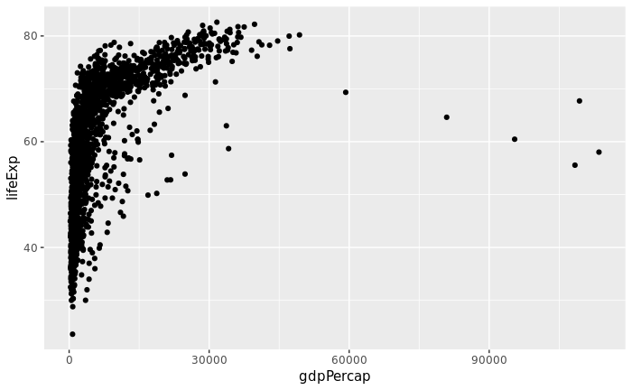

```r
ggplot(data = gapminder, mapping = aes(x = gdpPercap, y = lifeExp)) +
  geom_point()
```

So the first thing we do is call the `ggplot` function. This function lets R know that we’re creating a new plot, and any of the arguments we give the `ggplot` function are the global options for the plot: they apply to all layers on the plot.

We’ve passed in two arguments to `ggplot`. First, we tell ggplot what data we want to show on our figure, in this example the `gapminder` data we read in earlier. For the second argument, we passed in the `aes` function, which tells ggplot how variables in the data map to aesthetic properties of the figure, in this case the `x` and `y` locations. Here we told ggplot we want to plot the “gdpPercap” column of the gapminder data frame on the x-axis, and the “lifeExp” column on the y-axis. Notice that we didn’t need to explicitly pass `aes` these columns (e.g. `x = gapminder[, "gdpPercap"]`), this is because ggplot is smart enough to know to look in the data for that column!

By itself, the call to ggplot isn’t enough to draw a figure:

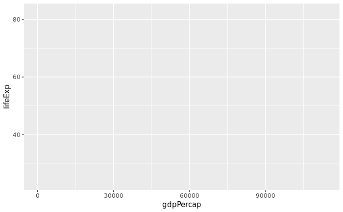

```r
ggplot(data = gapminder, mapping = aes(x = gdpPercap, y = lifeExp))
```

We need to tell `ggplot` how we want to visually represent the data, which we do by adding a new geom layer. In our example, we used `geom_point`, which tells `ggplot` we want to visually represent the relationship between `x` and `y` as a scatterplot of points:

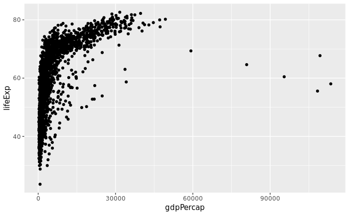

```r
ggplot(data = gapminder, mapping = aes(x = gdpPercap, y = lifeExp)) + geom_point()
```

All ggplot2 plots begin with a call to `ggplot()`, supplying default `data` and aesthethic mappings, specified by `aes()`. You then add layers, scales, coords and facets with `+`. To save a plot to disk, use `ggsave()`.

```r
# save a plot

p = ggplot(data = gapminder, mapping = aes(x = gdpPercap, y = lifeExp)) + geom_point()

ggsave("plot1.pdf", p, device = "pdf")
```

More examples of `ggplot2`:

Make boxplot to show `lifeExp` of each continents

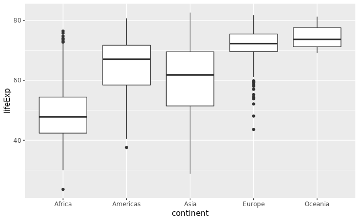

```r
ggplot(gapminder, aes(x = continent, y = lifeExp)) + geom_boxplot()
```

Another way to show the data

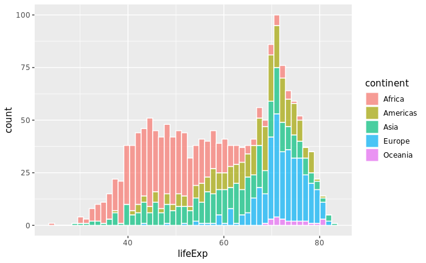

```r
ggplot(gapminder) + geom_histogram(aes(lifeExp, fill=continent), bins=50, color="white", alpha=0.7)
```

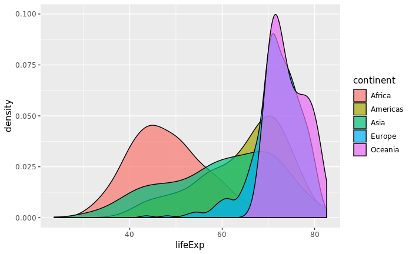

```r
ggplot(gapminder) + geom_density(aes(lifeExp, fill=continent), alpha=0.7)
```